# Homework 12

Anna Schmidt

4/13/2022

**1. For this exercise, use your newly-developed ggplot chops to create some nice graphs from your own data (If you do not have a good data frame to use for graphics, use one of the many built-in data frames from R (other than mpg, which we are using in class)). Experiment with different themes, theme base sizes, aesthetics, mappings, and faceting. When you are finished, try exporting them to high quality pdfs, jpgs, eps files, or other formats that you would use for submission to a journal.**

(In this exercise, I encourage you to improve your graphics with elements that we have not (yet) covered in ggplot. For example, can you change the labels on a facet plot so that they are more informative than the variable names that are supplied from your data frame? Can you figure out how to add text annotations, lines and arrows to your graph? Can you figure out how to use custom colors that you have chosen for your fills and lines? Your resources for these explorations are google, Stack Overflow – and your TAs!)

I am going to be making some ggplot figures from some data I have been analyzing showing zooplankton biomass across 16 experimental ponds that we sampled.

##### Part I: Zooplankton biomass across lakes

The first graph I am going to create is a faceted stacked bar plot that summarizes the zooplankton biomass data that we have for each lake, habitat, and time of day that we sampled. I am going to bring in this data from an R object that I created from a data frame in my data analysis script for this project.

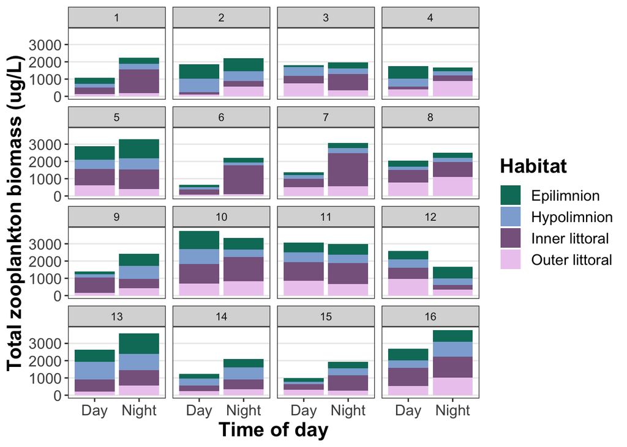

```r
# Load packages
library(ggplot2)

# Bring in the R object

my_data <- readRDS(file = "my_data.rds")

# Plot zooplankton biomass, faceted by lake, stacked bars representing each habitat sampled in each lake

p1 <- ggplot(my_data, aes(x = time.of.day,
                          y = total.biomass,
                          fill = habitat)) +
  geom_bar(stat="identity") +
  facet_wrap(vars(pondID)) + # facet by pondID
  labs(x = "Time of day", # x axis label
       y = "Total zooplankton biomass (ug/L)", # y axis label
       fill = "Habitat") + # legend label
  scale_fill_manual(values = c('EP' = "#067B67",
                               'HP' = "#8DADD6",
                               'IL' = "#87648C",
                               'OL' = "#EDCCEF"),
                    labels = c('Epilimnion', # change EP to Epilimnion in legend
                               'Hypolimnion', # change HP to Hypolimnion in legend
                               'Inner littoral', # change IL to Inner littoral in legend
                               'Outer littoral')) + # change OL to Outer littoral in legend
  theme_bw() +
  theme(panel.grid.major.x = element_blank(),
        panel.grid.minor.x = element_blank(),
        panel.grid.minor.y = element_blank()) +
  scale_x_discrete(labels = c("D" = "Day","N" = "Night")) + # change D and N to Day and Night in x-axis
  theme(axis.text=element_text(size=12),
        axis.title=element_text(size=16,face="bold"),
        legend.text=element_text(size=12),
        legend.title=element_text(size=16, face="bold"))

print(p1)
```

```r
# Export to a pdf and save to my R project
ggsave(plot = p1,
       filename = "ZooplanktonBiomass.pdf",
       width = 10, height = 8, units = "in", device = "pdf")
```

The lakes (#1-16) are automatically positioned in increasing order in this figure. The lakes in this system are experimentally manipulated with four different treatments, with four lakes per treatment. Because of this, I wanted to sort the lakes in this figure by their treatment instead of by their ordered numbering. I want each row of lakes in this figure to contain the four lakes of a certain treatment. To do this, I first reordered the pondID column according to which treatment corresponds to each pondID, then repeated the ggplot plotting code from above.

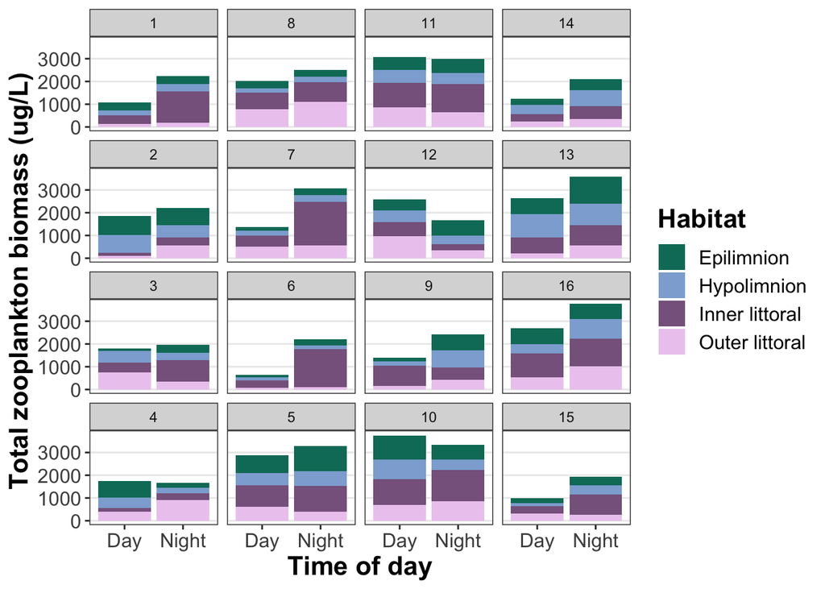

```r
# Reorder lakes by treatment (first four lakes are a certain treatment, then the next four lakes are another treatment, etc.)
my_data$pondID <- factor(my_data$pondID ,
                         levels = c("1", "8", "11", "14",
                                    "2", "7", "12", "13",
                                    "3", "6", "9", "16",
                                    "4", "5", "10", "15"))

# Plot zooplankton biomass, faceted by lake, stacked bars representing each habitat sampled in each lake

p1a <- ggplot(my_data, aes(x = time.of.day,
                          y = total.biomass,
                          fill = habitat)) +
  geom_bar(stat="identity") +
  facet_wrap(vars(pondID)) + # facet by pondID
  labs(x = "Time of day", # x axis label
       y = "Total zooplankton biomass (ug/L)", # y axis label
       fill = "Habitat") + # legend label
  scale_fill_manual(values = c('EP' = "#067B67",
                               'HP' = "#8DADD6",
                               'IL' = "#87648C",
                               'OL' = "#EDCCEF"),
                    labels = c('Epilimnion', # change EP to Epilimnion in legend
                               'Hypolimnion', # change HP to Hypolimnion in legend
                               'Inner littoral', # change IL to Inner littoral in legend
                               'Outer littoral')) + # change OL to Outer littoral in legend
  theme_bw() +
  theme(panel.grid.major.x = element_blank(),
        panel.grid.minor.x = element_blank(),
        panel.grid.minor.y = element_blank()) +
  scale_x_discrete(labels = c("D" = "Day","N" = "Night")) + # change D and N to Day and Night in x-axis
  theme(axis.text=element_text(size=12),
        axis.title=element_text(size=16,face="bold"),
        legend.text=element_text(size=12),
        legend.title=element_text(size=16, face="bold"))

print(p1a)
```

```r
# Export to a pdf and save to my R project
ggsave(plot = p1a,
       filename = "ZooplanktonBiomass_treatment_rows.pdf",
       width = 10, height = 8, units = "in", device = "pdf")
```

Now, the lakes are reordered by treatment so they can be compared more easily within and across treatments.

##### Part II: Drivers of zooplankton migration

The second graph I am going to create is a scatterplot with a linear regression investigating drivers of vertical migration of zooplankton. The x-axis (explanatory variable) will be either a gradient of planktivory or a gradient of oxygen conditions, and the y-axis (response variable) will be a metric for vertical migration of zooplankton. I will be looking for linear trends between these variables using linear regressions. As above, I am going to bring in this data from an R object that I created from a data frame in my data analysis script for this project.

```r
# Bring in the R object

migration <- readRDS(file = "migration_drivers.rds")
```

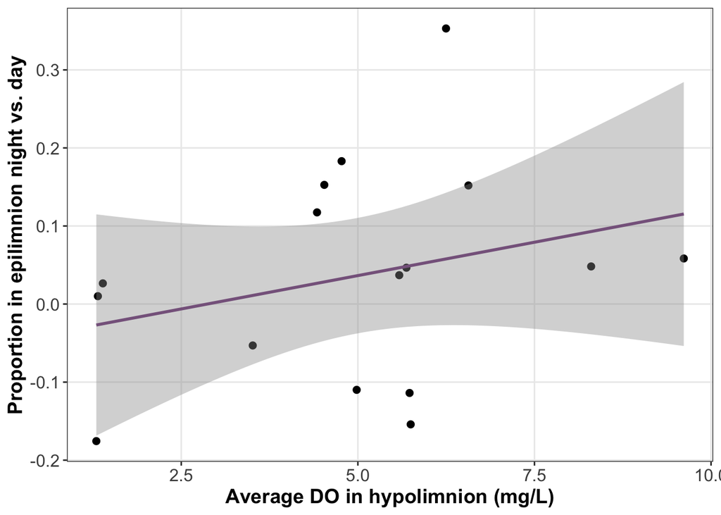

```r
# Plot the impacts of oxygen gradient on vertical migration metric

p2 <- ggplot(migration, aes(x = avg_do_mgL,
                            y = proportion_nminusd)) +
  geom_point(size=2) +
  stat_smooth(method = lm, color = "#87648C") + # add linear regression line and shaded CI
  labs(x = "Average DO in hypolimnion (mg/L)",  # x axis label
       y = "Proportion in epilimnion night vs. day") + # y axis label
  theme_bw() +
  theme(panel.grid.minor = element_blank()) +
  theme(axis.text=element_text(size=12),
        axis.title=element_text(size=14,face="bold"))

print(p2)
```

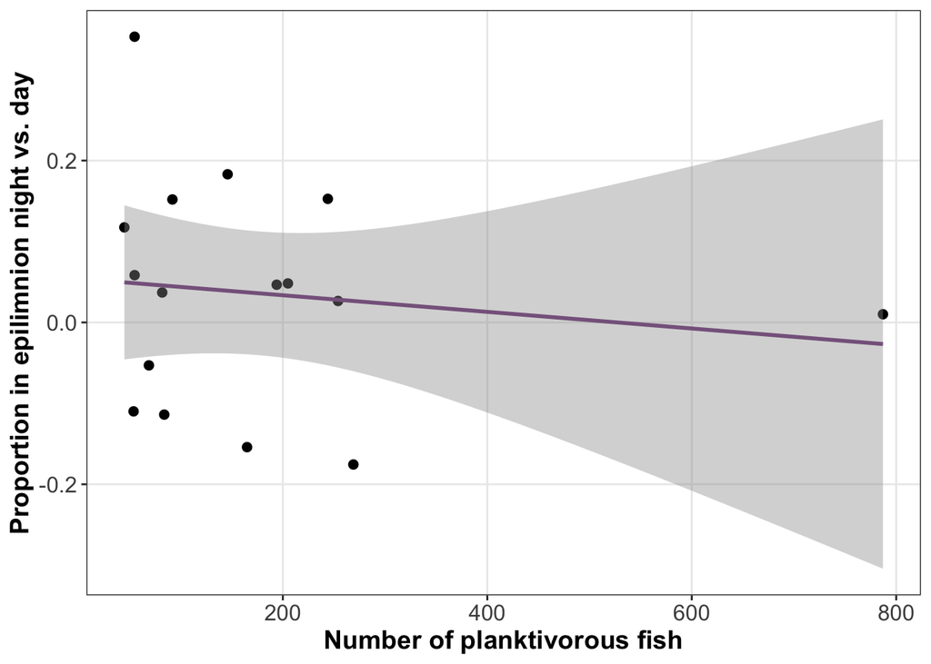

```r
# Export to a pdf and save to my R project
ggsave(plot = p2, filename = "Oxygen_vs_DVM.pdf",
       width = 10, height = 8, units = "in", device = "pdf")
# Plot the impacts of planktivory gradient on vertical migration metric

p3 <- ggplot(migration, aes(x = nfish,
                            y = proportion_nminusd,)) +
  geom_point(size=2) +
  stat_smooth(method=lm, color = "#87648C") + # add linear regression line and shaded CI
  labs(x = "Number of planktivorous fish",  # x axis label
       y = "Proportion in epilimnion night vs. day", ) + # y axis label
  theme_bw() +
  theme(panel.grid.minor = element_blank()) +
  theme(axis.text=element_text(size=12),
        axis.title=element_text(size=14,face="bold"))

print(p3)
```

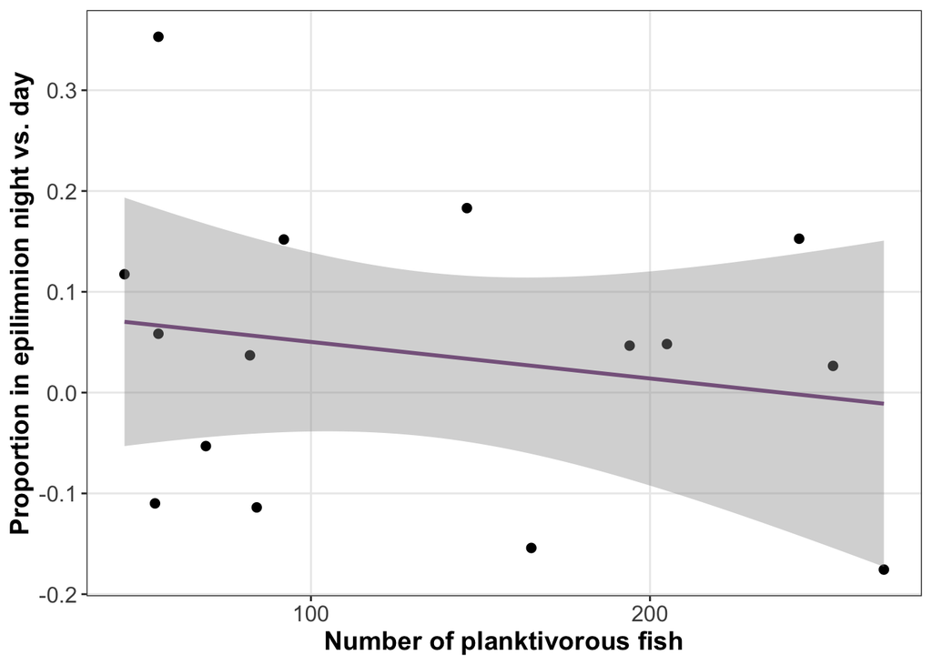

```r
# Export to a pdf and save to my R project
ggsave(plot = p3, filename = "Planktivory_vs_DVM.pdf",
       width = 10, height = 8, units = "in", device = "pdf")
# There is a large outlier for Lake 14, which had significantly more planktivorous fish than all of the other lakes. In order to look at the overall trend without this point biasing things, I am going to remove that point for our further analysis.

migration_subset <- subset(migration, pondID!="14") # remove lake 14 from the data frame

p4 <- ggplot(migration_subset, aes(x = nfish,
                                   y = proportion_nminusd,)) +
  geom_point(size=2) +
  stat_smooth(method=lm, color = "#87648C") + # add linear regression line and shaded CI
  labs(x = "Number of planktivorous fish",  # x axis label
       y = "Proportion in epilimnion night vs. day", ) + # y axis label
  theme_bw() +
  theme(panel.grid.minor = element_blank()) +
  theme(axis.text=element_text(size=12),
        axis.title=element_text(size=14,face="bold"))

print(p4)
```

```r
# Export to a pdf and save to my R project
ggsave(plot = p4, filename = "Planktivory_vs_DVM_nolake14.pdf",
       width = 10, height = 8, units = "in", device = "pdf")
```

Since I am investigating whether linear trends exist between these variables using linear regressions, I want to print the R2 value and slope p-value on the graphs.

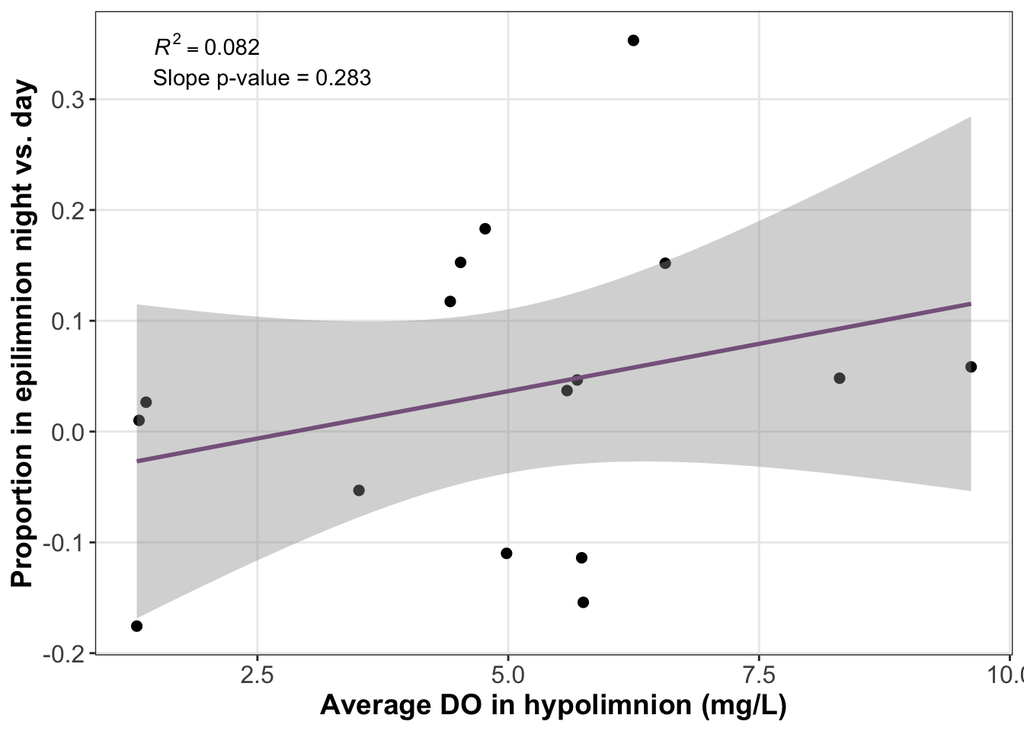

```r
# Linear regression analysis: impacts of oxygen gradient on vertical migration metric

regression <- lm(proportion_nminusd ~ avg_do_mgL, data = migration) # linear regression

z <- unlist(summary(regression)) # unlist model summary

reg_summary <- list(slopeP = z$coefficients8, # p-value
                    R2 = z$r.squared) # multiple R-squared

# Add the slope and R2 to the top left corner of p2
p2 + annotate("text", x = 2, y = 0.35,
              label = paste("italic(R) ^ 2 ==", round(reg_summary$R2, 3)),
              parse = TRUE) +
  annotate("text", x = 2.55, y = 0.32,
           label = paste("Slope p-value =", round(reg_summary$slopeP, 3)))
```

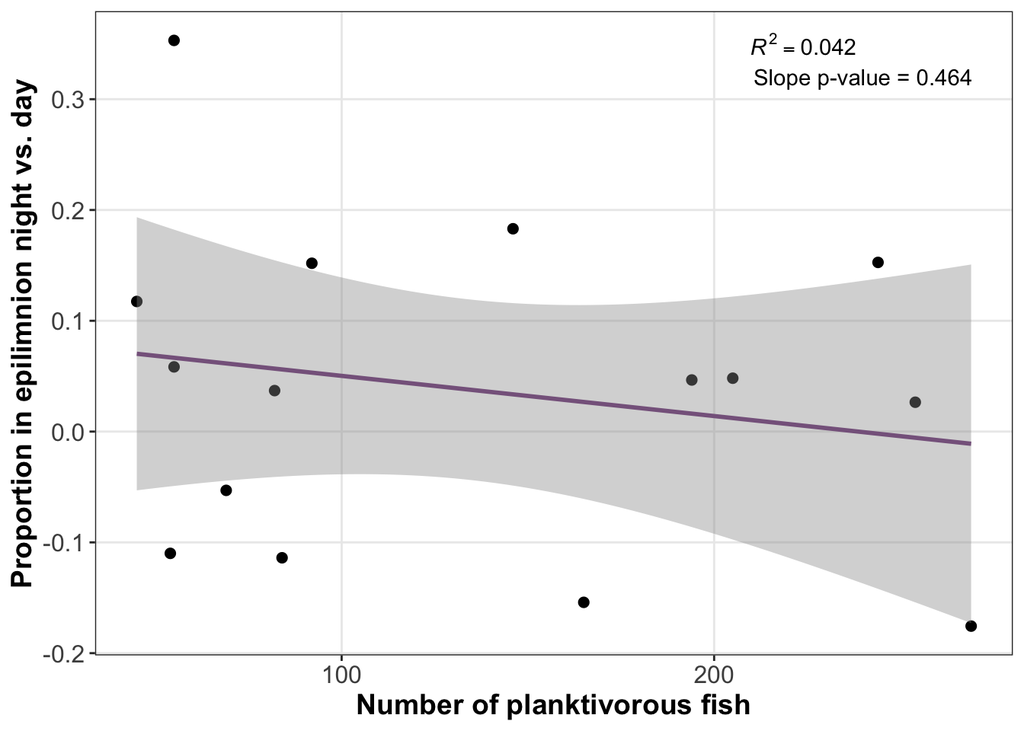

```r
# Linear regression analysis: impacts of planktivory gradient on vertical migration metric

regression <- lm(proportion_nminusd ~ nfish, data = migration_subset) # linear regression

z <- unlist(summary(regression)) # unlist model summary

reg_summary <- list(slopeP = z$coefficients8, # p-value
                    R2 = z$r.squared) # multiple R-squared

# Add the slope and R2 to the top left corner of p4
p4 + annotate("text", x = 224, y = 0.35,
              label = paste("italic(R) ^ 2 ==", round(reg_summary$R2, 3)),
              parse = TRUE) +
  annotate("text", x = 240, y = 0.32,
           label = paste("Slope p-value =", round(reg_summary$slopeP, 3)))
```

##### Part III: Trying mapping in ggplot

Unrelated to the data above, I wanted to learn how to create maps in R / ggplot. I got information from https://r-spatial.org/r/2018/10/25/ggplot2-sf.html, http://mbontrager.org/blog/2016/08/01/Maps-in-R, and https://stackoverflow.com/questions/68219487/how-to-make-the-great-lakes-the-same-color-as-the-ocean-in-r which I adapt below to make some maps!

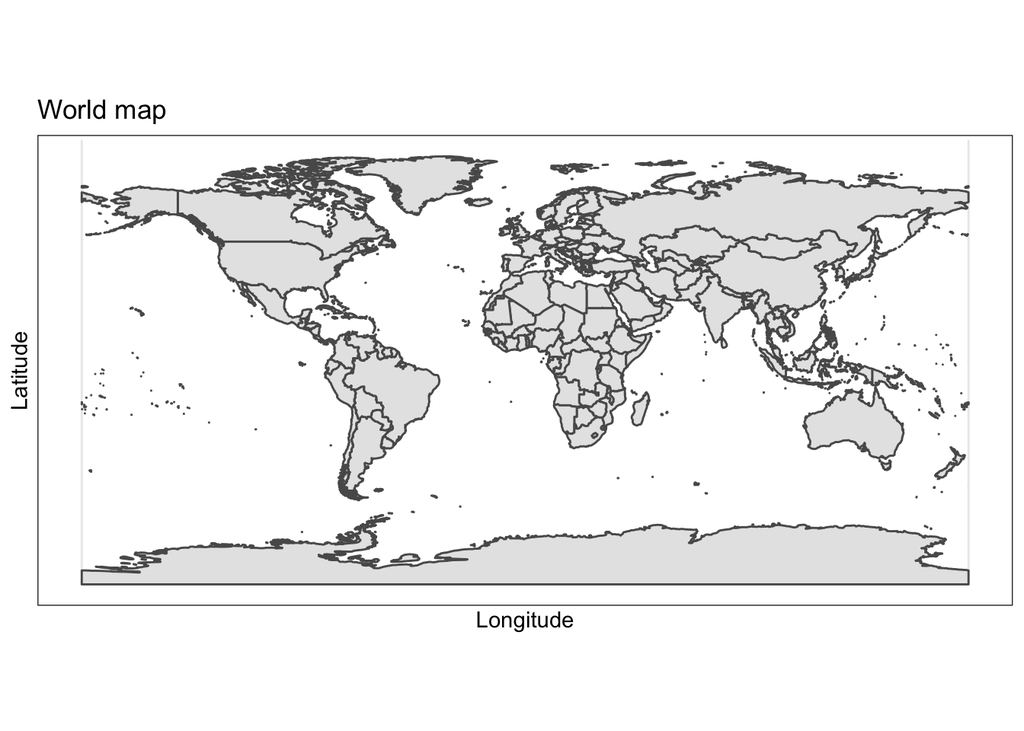

```r
# Load packages
library(ggplot2)
library(sf)
library(rnaturalearth)
library(rnaturalearthdata)
library(ggspatial)

theme_set(theme_bw())

world <- ne_countries(scale = "medium", returnclass = "sf")

# plot world map
ggplot(data = world) +
    geom_sf() +
    xlab("Longitude") + ylab("Latitude") +
    ggtitle("World map")
```

```
## Scale on map varies by more than 10%, scale bar may be inaccurate
```

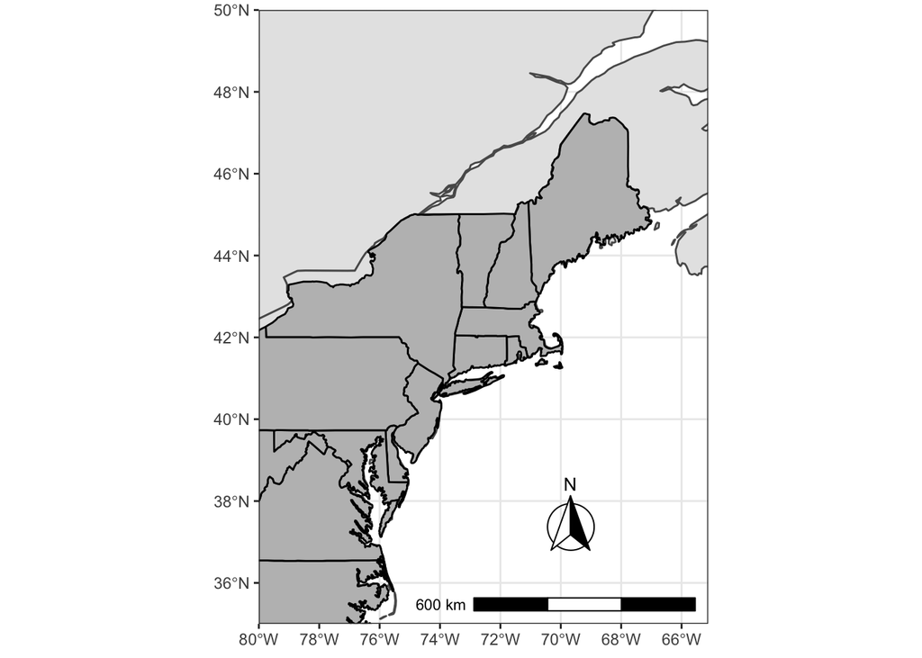

```r
# USA state outlines
usa_states <- st_as_sf(maps::map("state",
                                 fill=TRUE,
                                 plot =FALSE),
                       crs = 4269)

# zoom in on an area of interest, add scale bar and north arrow
ggplot(data = world) +
  geom_sf() +
  geom_sf(data = usa_states,
          mapping = aes(geometry = geom),
          color = "black",
          fill = "gray") +
  annotation_scale(location = "br", width_hint = 0.5) +  # add scale bar
  annotation_north_arrow(location = "br",  # add north arrow
                         which_north = "true",
                         pad_x = unit(0.75, "in"),
                         pad_y = unit(0.5, "in"),
                         style = north_arrow_fancy_orienteering) +
  coord_sf(xlim = c(-80, -65.12),  # zoom in on New Engand region
           ylim = c(35, 50),
           expand = FALSE)
```

Back to Home Page